Submitted by** : Abhinav Paul

Date** : 2025-07-18

# **Introduction**

This report presents the analysis of wage data, focusing on the relationship between wages, IQ, and education. The analysis follows the questions outlined in the assignment.

# **Data Loading and Setup**

First, let’s load the necessary packages and the dataset.

```r
# Load necessary packages
library(ggplot2)
library(dplyr)
library(readr)

# Load the data
wage2 <- read_csv("/Users/abhinavpaul/Desktop/Goals/Exec Edu/1. ISB AMPBA/Course Material/Term 2/1. SA2/Assignment/Final Submission/Wage2.csv")
```

# **Answers to Questions**

## **Question 1 to 3**

## **Question 4**

Here are the summary statistics for the variables wages and IQ in the given sample data

```r
# Calculate summary statistics
summary_wage <- wage2 %>%
  summarise(
    avg_wage = mean(wage, na.rm = TRUE),
    min_wage = min(wage, na.rm = TRUE),
    max_wage = max(wage, na.rm = TRUE)
  )

summary_IQ <- wage2 %>%
  summarise(
    avg_IQ = mean(IQ, na.rm = TRUE),
    min_IQ = min(IQ, na.rm = TRUE),
    max_IQ = max(IQ, na.rm = TRUE)
  )
```

#### **Wage Stats Summary**

```r
knitr::kable(summary_wage, caption = "Summary Wage")
```

Summary Wage

| avg_wage | min_wage | max_wage |
| --- | --- | --- |
| 928.6972 | 115 | 3078 |

#### **IQ Stats Summary**

```r
knitr::kable(summary_IQ, caption = "Summary IQ")
```

Summary IQ

| avg_IQ | min_IQ | max_IQ |
| --- | --- | --- |
| 101.0045 | 50 | 145 |

## **Question 5**

### **Scatterplot of Wage vs IQ**

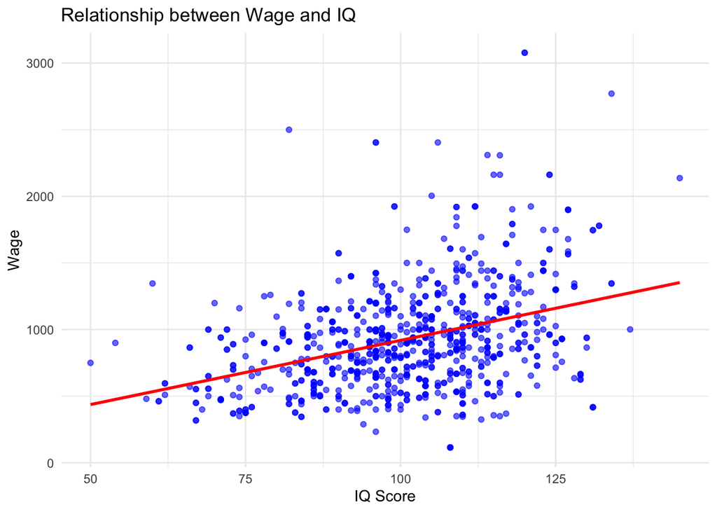

```r
ggplot(wage2, aes(x = IQ, y = wage)) +
  geom_point(color = 'blue', alpha = 0.6) +
  geom_smooth(method = 'lm', se = FALSE, color = 'red') +
  labs(title = "Relationship between Wage and IQ",
       x = "IQ Score",
       y = "Wage") +
  theme_minimal()
```

### **Observations**

##### **Direction** : Positive as the Wage is increasing with IQ metric

##### **Linearity** : Roughly Linear. There is lot of error around the linear line and the the wage data points

##### **Strength** : Weak to Moderate as the scatter plot is not tightly clustered around the Line

## **Question 6**

### **Correlation**

```r
cor_iq_wage <- cor(wage2$IQ, wage2$wage, use = "complete.obs")
cat("Correlation between IQ and wage:", round(cor_iq_wage, 4), "\n")
```

```
## Correlation between IQ and wage: 0.3725
```

### **Observations**

##### Given the Direction and strength in the scatter plot the correlation of 0.3725 makes sense to be positive but weak. There are lot of error in the Wage actual value from the Linear line of the Equation

## **Question 7**

### **Simple Linear Regression (Wage ~ IQ)**

```r
model1 <- lm(wage ~ IQ, data = wage2)
summary(model1)
```

```
##
## Call:
## lm(formula = wage ~ IQ, data = wage2)
##
## Residuals:
##     Min      1Q  Median      3Q     Max
## -881.11 -239.75  -36.74  188.53 1966.25
##
## Coefficients:
##             Estimate Std. Error t value Pr(>|t|)
## (Intercept) -44.6541    82.4987  -0.541    0.588
## IQ            9.6367     0.8078  11.929   <2e-16 ***
## ---
## Signif. codes:  0 '***' 0.001 '**' 0.01 '*' 0.05 '.' 0.1 ' ' 1
##
## Residual standard error: 362.4 on 883 degrees of freedom
## Multiple R-squared:  0.1388, Adjusted R-squared:  0.1378
## F-statistic: 142.3 on 1 and 883 DF,  p-value: < 2.2e-16
```

## **Question 8**

### **Hypothesis Test**

#### **Null hypothesis**: Beta_hat_1 = 0 i.e. IQ is not (linearly) associated with wage.

#### **Alternative hypothesis**: Beta_hat_1 <> 0 i.e. IQ is (linearly) associated with wage.

## **Question 9**

#### Rejected null hypothesis at 5% significance level since p-value (2.2e-16) < alpha (0.05)

## **Question 10**

### **Multiple Regression (Wage ~ IQ + Education)**

```r
model2 <- lm(wage ~ IQ + educ, data = wage2)
summary(model2)
```

```
##
## Call:
## lm(formula = wage ~ IQ + educ, data = wage2)
##
## Residuals:
##     Min      1Q  Median      3Q     Max
## -847.98 -223.83  -23.17  191.46 2006.49
##
## Coefficients:
##              Estimate Std. Error t value Pr(>|t|)
## (Intercept) -270.2086    88.2542  -3.062  0.00227 **
## IQ             6.3798     0.9434   6.763 2.46e-11 ***
## educ          41.1528     6.5043   6.327 3.97e-10 ***
## ---
## Signif. codes:  0 '***' 0.001 '**' 0.01 '*' 0.05 '.' 0.1 ' ' 1
##
## Residual standard error: 354.6 on 882 degrees of freedom
## Multiple R-squared:  0.1762, Adjusted R-squared:  0.1743
## F-statistic: 94.31 on 2 and 882 DF,  p-value: < 2.2e-16
```

## **Question 11**

### **Education Statistics**

```r
educ_stats <- wage2 %>%
  summarise(
    avg_educ = mean(educ, na.rm = TRUE),
    min_educ = min(educ, na.rm = TRUE),
    max_educ = max(educ, na.rm = TRUE)
  )

knitr::kable(educ_stats, caption = "Education Statistics")
```

Education Statistics

| avg_educ | min_educ | max_educ |
| --- | --- | --- |
| 13.47458 | 9 | 18 |

## **Question 13**

### **Omitted Variable Bias Check**

```r
model3 <- lm(educ ~ IQ, data = wage2)
summary(model3)
```

```
##
## Call:
## lm(formula = educ ~ IQ, data = wage2)
##
## Residuals:
##     Min      1Q  Median      3Q     Max
## -4.0785 -1.3159 -0.2871  1.2595  6.0295
##
## Coefficients:
##             Estimate Std. Error t value Pr(>|t|)
## (Intercept)  5.48091    0.41771   13.12   <2e-16 ***
## IQ           0.07914    0.00409   19.35   <2e-16 ***
## ---
## Signif. codes:  0 '***' 0.001 '**' 0.01 '*' 0.05 '.' 0.1 ' ' 1
##
## Residual standard error: 1.835 on 883 degrees of freedom
## Multiple R-squared:  0.2977, Adjusted R-squared:  0.297
## F-statistic: 374.4 on 1 and 883 DF,  p-value: < 2.2e-16
```

```r
delta_tilda_1 <- coef(model3)["IQ"]
beta_hat_2 <- coef(model2)["educ"]
beta_hat_1 <- coef(model2)["IQ"]
beta_tilde_1 <- coef(model1)["IQ"]

# beta_tilde_1 = beta_hat_1 + (beta_hat_2 * delta_tilda_1)
lhs <- as.numeric(beta_tilde_1)
rhs <- as.numeric(beta_hat_1 + beta_hat_2 * delta_tilda_1)

ovb_results <- data.frame(
  Left_Hand_Side = round(lhs,3),
  Right_Hand_Side = round(rhs,3),
  Match = (round(lhs,3)==round(rhs,3))
)

knitr::kable(ovb_results, caption = "Omitted Variable Bias Check")
```

Omitted Variable Bias Check

| Left_Hand_Side | Right_Hand_Side | Match |
| --- | --- | --- |
| 9.637 | 9.637 | TRUE |

## **Question 14**

### **Predicted vs Actual Wage for First Individual**

```r
predicted_wage <- predict(model2, newdata = wage2[1, ])
actual_wage <- wage2$wage[1]
difference <- actual_wage - predicted_wage

prediction_results <- data.frame(
  Predicted_Wage = predicted_wage,
  Actual_Wage = actual_wage,
  Difference = difference
)

knitr::kable(prediction_results, caption = "Prediction Results for First Individual")
```

Prediction Results for First Individual

| Predicted_Wage | Actual_Wage | Difference |
| --- | --- | --- |
| 855.2258 | 700 | -155.2258 |

### **Observation**

##### **Predicted wage for first person (model 2 ~ Multiple Regression (Wage ~ IQ + Education))** : Rs. 855,225.8

##### **Actual wage** : Rs. 700,000

##### **Difference** : - Rs. 155,225.8 i.e. Individual is underpaid compared to model prediction

# **Conclusion**

This analysis explored the relationship between wages, IQ, and education. The regression results suggest that both IQ and education have statistically significant effects on wages. The omitted variable bias check confirms the theoretical relationship between the simple and multiple regression coefficients.